# Practical Machine Learning

# Background and Introduction

Using devices such as Jawbone Up, Nike FuelBand, and Fitbit it is now possible to collect a large amount of data about personal activity relatively inexpensively. These type of devices are part of the quantified self movement - a group of enthusiasts who take measurements about themselves regularly to improve their health, to find patterns in their behavior, or because they are tech geeks.

One thing that people regularly do is quantify how much of a particular activity they do, but they rarely quantify how well they do it. In this project, we will use data recorded from accelerometers on the belt, forearm, arm, and dumbbell of 6 participants. They were asked to perform barbell lifts correctly and incorrectly in 5 different ways.

More information is available from the website http://groupware.les.inf.puc-rio.br/har (see the section on the Weight Lifting Exercise Dataset).

The goal of this project is to predict the manner in which the participants did the exercise. This is the classe variable of the training set, which classifies the correct and incorrect outcomes into A, B, C, D, and E categories. This report describes how the model for the project was built, its cross validation, expected out of sample error calculation, and the choices made. It was used successfully to accurately predict all 20 different test cases on the Coursera website.

This document is the write-up submission for the course Practical Machine Learning by Jeff Leek, PhD, Professor at Johns Hopkins University, Bloomberg School of Public Health. This 4-week course was offered on Coursera in June 2015, and is part of Johns Hopkins Data Science Specialization.

## Data description

The training data for this project are available here: https://d396qusza40orc.cloudfront.net/predmachlearn/pml-training.csv

The test data are available here: https://d396qusza40orc.cloudfront.net/predmachlearn/pml-testing.csv

The data for this project come from this source: http://groupware.les.inf.puc-rio.br/har

We first download the data from the links referenced above to our computer and upload the files into R (using RStudio), interpreting the miscellaneous NA, #DIV/0! and empty fields as NA:

```r
pml.training <- read.csv("~/Downloads/pml-training.csv",na.strings = c("NA","#DIV/0!"," "))
pml.testing <- read.csv("~/Downloads/pml-testing.csv",na.strings =c("NA","#DIV/0!"," "))
```

We take a quick look at the data and particularly at classe which is the variable we need to predict:

```r
dim(pml.training)
```

```
## [1] 19622   160
```

```r
dim(pml.testing)
```

```
## [1]  20 160
```

```r
str(pml.training,list.len=15)
```

```
## 'data.frame':    19622 obs. of  160 variables:
##  $ X                       : int  1 2 3 4 5 6 7 8 9 10 ...
##  $ user_name               : Factor w/ 6 levels "adelmo","carlitos",..: 2 2 2 2 2 2 2 2 2 2 ...
##  $ raw_timestamp_part_1    : int  1323084231 1323084231 1323084231 1323084232 1323084232 1323084232 1323084232 1323084232 1323084232 1323084232 ...
##  $ raw_timestamp_part_2    : int  788290 808298 820366 120339 196328 304277 368296 440390 484323 484434 ...
##  $ cvtd_timestamp          : Factor w/ 20 levels "02/12/2011 13:32",..: 9 9 9 9 9 9 9 9 9 9 ...
##  $ new_window              : Factor w/ 2 levels "no","yes": 1 1 1 1 1 1 1 1 1 1 ...
##  $ num_window              : int  11 11 11 12 12 12 12 12 12 12 ...
##  $ roll_belt               : num  1.41 1.41 1.42 1.48 1.48 1.45 1.42 1.42 1.43 1.45 ...
##  $ pitch_belt              : num  8.07 8.07 8.07 8.05 8.07 8.06 8.09 8.13 8.16 8.17 ...
##  $ yaw_belt                : num  -94.4 -94.4 -94.4 -94.4 -94.4 -94.4 -94.4 -94.4 -94.4 -94.4 ...
##  $ total_accel_belt        : int  3 3 3 3 3 3 3 3 3 3 ...
##  $ kurtosis_roll_belt      : num  NA NA NA NA NA NA NA NA NA NA ...
##  $ kurtosis_picth_belt     : num  NA NA NA NA NA NA NA NA NA NA ...
##  $ kurtosis_yaw_belt       : logi  NA NA NA NA NA NA ...
##  $ skewness_roll_belt      : num  NA NA NA NA NA NA NA NA NA NA ...
##   [list output truncated]
```

```r
trainingset<-pml.training[,colSums(is.na(pml.training)) == 0]
testingset<-pml.testing[,colSums(is.na(pml.training)) == 0]
```

```r
trainingset<-trainingset[,-c(1:7)]
testingset<-testingset[,-c(1:7)]
dim(trainingset)
```

```
## [1] 19622    53
```

```r
dim(testingset)
```

```
## [1] 20 53
```

```r
library(caret)
```

```r
library(ggplot2)
library(randomForest)
library(rpart)
library(rpart.plot)
intrain<-createDataPartition(y=trainingset$classe,p=.75,list=FALSE)
train<-trainingset[intrain,]
test<-trainingset[-intrain,]
dim(train)
```

```
## [1] 14718    53
```

```r
dim(test)
```

```
## [1] 4904   53
```

### Barchart for outcome varible

The variable “classe” contains 5 levels: A, B, C, D and E. A plot of the outcome variable will allow us to see the frequency of each levels in the subTraining data set and compare one another.

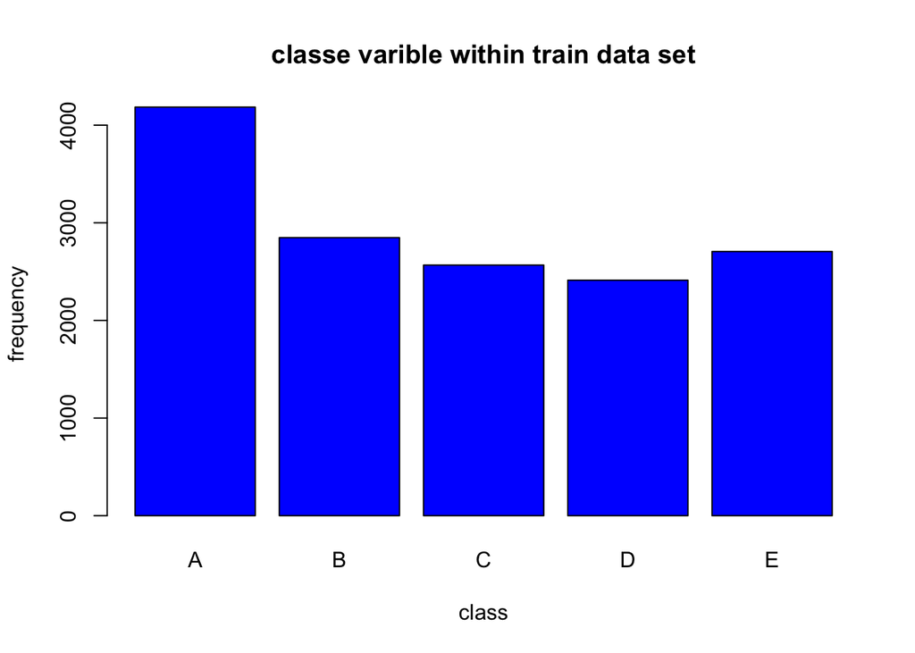

```r
plot(train$classe,xlab="class",ylab="frequency",col="blue",main="classe varible within train data set")
```

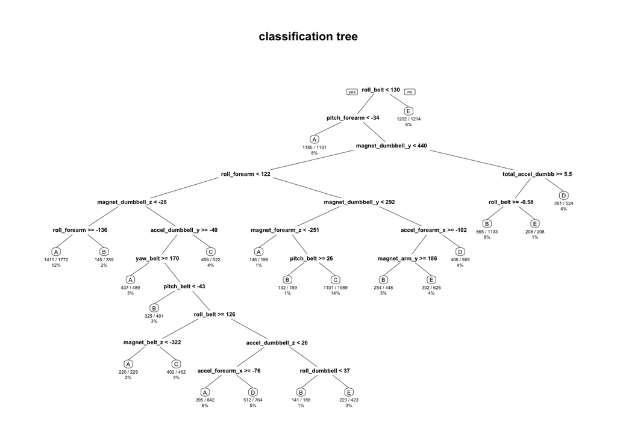

```r
rfmodel<-rpart(classe~.,data=train,method="class")

##prediction
prediction<-predict(rfmodel,test,type="class")

##decision treee plot
rpart.plot(rfmodel,main="classification tree",extra = 102,under = TRUE,faclen = 0)
```

```r
##confusion matrix
confusionMatrix(prediction,test$classe)
```

```
## Confusion Matrix and Statistics
##
##           Reference
## Prediction    A    B    C    D    E
##          A 1256  156   55   89   20
##          B   42  598   89   83   68
##          C   37   73  637  123  111
##          D   38   81   48  432   29
##          E   22   41   26   77  673
##
## Overall Statistics
##
##                Accuracy : 0.7333
##                  95% CI : (0.7207, 0.7456)
##     No Information Rate : 0.2845
##     P-Value [Acc > NIR] : < 2.2e-16
##
##                   Kappa : 0.6609
##  Mcnemar's Test P-Value : < 2.2e-16
##
## Statistics by Class:
##
##                      Class: A Class: B Class: C Class: D Class: E
## Sensitivity            0.9004   0.6301   0.7450  0.53731   0.7469
## Specificity            0.9088   0.9287   0.9150  0.95220   0.9585
## Pos Pred Value         0.7970   0.6795   0.6493  0.68790   0.8021
## Neg Pred Value         0.9582   0.9128   0.9444  0.91300   0.9439
## Prevalence             0.2845   0.1935   0.1743  0.16395   0.1837
## Detection Rate         0.2561   0.1219   0.1299  0.08809   0.1372
## Detection Prevalence   0.3214   0.1794   0.2000  0.12806   0.1711
## Balanced Accuracy      0.9046   0.7794   0.8300  0.74475   0.8527
```

## Second Prediction Model:using Random Forest

```r
rfmodel2<-randomForest(classe~.,train,method="class")
rfmodel2
```

```
##
## Call:
##  randomForest(formula = classe ~ ., data = train, method = "class")
##                Type of random forest: classification
##                      Number of trees: 500
## No. of variables tried at each split: 7
##
##         OOB estimate of  error rate: 0.48%
## Confusion matrix:
##      A    B    C    D    E  class.error
## A 4182    3    0    0    0 0.0007168459
## B   13 2831    4    0    0 0.0059691011
## C    0   18 2547    2    0 0.0077911959
## D    0    0   23 2387    2 0.0103648425
## E    0    0    2    4 2700 0.0022172949
```

```r
prediction2<-predict(rfmodel2,test,type="class")
confusionMatrix(prediction2,test$classe)
```

```
## Confusion Matrix and Statistics
##
##           Reference
## Prediction    A    B    C    D    E
##          A 1394    8    0    0    0
##          B    0  941    1    0    0
##          C    0    0  853    5    0
##          D    0    0    1  798    2
##          E    1    0    0    1  899
##
## Overall Statistics
##
##                Accuracy : 0.9961
##                  95% CI : (0.994, 0.9977)
##     No Information Rate : 0.2845
##     P-Value [Acc > NIR] : < 2.2e-16
##
##                   Kappa : 0.9951
##  Mcnemar's Test P-Value : NA
##
## Statistics by Class:
##
##                      Class: A Class: B Class: C Class: D Class: E
## Sensitivity            0.9993   0.9916   0.9977   0.9925   0.9978
## Specificity            0.9977   0.9997   0.9988   0.9993   0.9995
## Pos Pred Value         0.9943   0.9989   0.9942   0.9963   0.9978
## Neg Pred Value         0.9997   0.9980   0.9995   0.9985   0.9995
## Prevalence             0.2845   0.1935   0.1743   0.1639   0.1837
## Detection Rate         0.2843   0.1919   0.1739   0.1627   0.1833
## Detection Prevalence   0.2859   0.1921   0.1750   0.1633   0.1837
## Balanced Accuracy      0.9985   0.9957   0.9982   0.9959   0.9986
```

# Submission

```r
predictfinal<-predict(rfmodel2,testingset,type="class")
predictfinal
```

```
##  1  2  3  4  5  6  7  8  9 10 11 12 13 14 15 16 17 18 19 20
##  B  A  B  A  A  E  D  B  A  A  B  C  B  A  E  E  A  B  B  B
## Levels: A B C D E
```

```r
pml_write_files = function(x){
  n = length(x)
  for(i in 1:n){
    filename = paste0("problem_id_",i,".txt")
    write.table(x[i],file=filename,quote=FALSE,row.names=FALSE,col.names=FALSE)
  }
}

pml_write_files(predictfinal)
```